# Eksploracyjna analiza danych dotyczących nieruchomości

Kacper Grzykowski, Dominik Kędzierski, Jakub Piwko

Marzec 2022

## Wczytanie danych

```r
source("data_loading.R")
real_estate1 <- load_data_EDA()
```

```r
str(real_estate1)
```

```
## tibble [2,919 x 82] (S3: tbl_df/tbl/data.frame)
##  $ Id           : int [1:2919] 1 2 3 4 5 6 7 8 9 10 ...
##  $ MSSubClass   : int [1:2919] 60 20 60 70 60 50 20 60 50 190 ...
##  $ MSZoning     : chr [1:2919] "RL" "RL" "RL" "RL" ...
##  $ LotFrontage  : int [1:2919] 65 80 68 60 84 85 75 NA 51 50 ...
##  $ LotArea      : int [1:2919] 8450 9600 11250 9550 14260 14115 10084 10382 6120 7420 ...
##  $ Street       : chr [1:2919] "Pave" "Pave" "Pave" "Pave" ...
##  $ Alley        : chr [1:2919] NA NA NA NA ...
##  $ LotShape     : chr [1:2919] "Reg" "Reg" "IR1" "IR1" ...
##  $ LandContour  : chr [1:2919] "Lvl" "Lvl" "Lvl" "Lvl" ...
##  $ Utilities    : chr [1:2919] "AllPub" "AllPub" "AllPub" "AllPub" ...
##  $ LotConfig    : chr [1:2919] "Inside" "FR2" "Inside" "Corner" ...
##  $ LandSlope    : chr [1:2919] "Gtl" "Gtl" "Gtl" "Gtl" ...
##  $ Neighborhood : chr [1:2919] "CollgCr" "Veenker" "CollgCr" "Crawfor" ...
##  $ Condition1   : chr [1:2919] "Norm" "Feedr" "Norm" "Norm" ...
```

[output cut: 68 more lines]

W ramce znajdują się 82 kolumny i 2919 rekordów. Kolumny reprezentują dane zarówno numeryczne jak i tesktowe.

## Unikalność i braki danych

```r
dim(unique(real_estate1))[1]/dim(real_estate1)[1]
```

```
## [1] 1
```

Wszystkie dane są unikalne

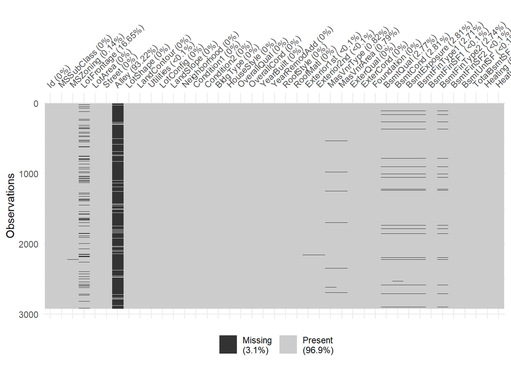

```r
vis_miss(real_estate1[1:41])
```

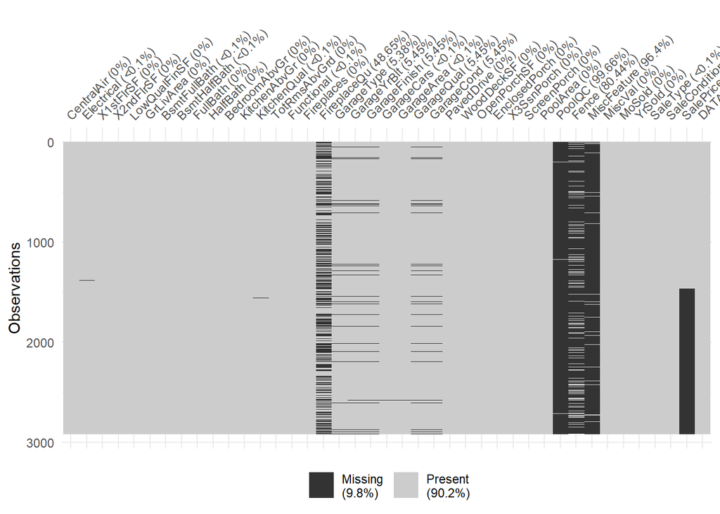

```r
vis_miss(real_estate1[42:82])
```

Jak widać w naszych danych występują kolumny z brakami danych. Jednak większość z nich występuje w specyficznym kontekście, ponieważ dotyczą głównie kolumn opisujących wyposażenie lub specyficzne pomieszczenia w mieszkaniu. Wartość NA ma oznaczać brak ‘funkcji’ w domu. Dlatego zamienimy wartości w tego typu kolumnach na “Absent” w przypadku kolumn typu string, natomiast na -1 w przypadku kolumn liczbowych.

```r
names_col <- c("FireplaceQu", "GarageType", "GarageYrBlt", "GarageFinish", "GarageQual", "GarageCond", "PoolQC", "Fence", "MiscFeature", "Alley", "BsmtQual", "BsmtCond", "BsmtExposure", "BsmtFinType1", "BsmtFinType2")
real_estate <- real_estate1
for (i in 1:(length(names_col))) {
  n <- names_col[i]
  atr <- real_estate[[n]]
  if (is.character(atr)) {
    atr[is.na(atr)] <- "Absent"
    real_estate[n] <- atr
  }
  if (is.numeric(atr)) {
    atr[is.na(atr)] <- "-1"
    real_estate[n] <- atr
  }
}
```

## Analiza rodzajów kolumn

```r
introduce(real_estate)
```

```
## # A tibble: 1 x 9
##    rows columns discrete_columns continuous_columns all_missing_columns
##   <int>   <int>            <int>              <int>               <int>
## 1  2919      82               45                 37                   0
## # ... with 4 more variables: total_missing_values <int>, complete_rows <int>,
## #   total_observations <int>, memory_usage <dbl>
```

Funkcja introduce rozpoznała w naszej kolumnie aż 37 kolumn ciągłych. Zapewne wynika to ze zliczenia kolumn numerycznych. Dużo kolumn numerycznych można jednak uznać za dyskretne, bo przyjmują wartości z ograniczonego zbioru np. liczba łazienek lub kuchni czy ocena ogólnych warunków.

```r
head(real_estate1[c("MSSubClass", "BsmtCond", "BsmtQual")])
```

```
## # A tibble: 6 x 3
##   MSSubClass BsmtCond BsmtQual
##        <int> <chr>    <chr>
## 1         60 TA       Gd
## 2         20 TA       Gd
## 3         60 TA       Gd
## 4         70 Gd       TA
## 5         60 TA       Gd
## 6         50 TA       Gd
```

Kolumna MSSubClass", która liczbami koduje typ nieruchomości może zostać zmieniona na typowo tekstową zmienną dyskretną. Natomiast kolumny opisujące jakość lub warunki niektórych elementów mieszkania, zamiast używać skrótów tekstowych, mogą używać skali liczbowej do oceny. Zmiany wymagają także inne kolumny, których wartości da się zakwalifikować jako reprezentujące relacje lepszy-gorszy.

```r
#Zamiana liczbowa -> tesktowa
real_estate <- real_estate %>%
  mutate(MSSubClass =
            case_when(
              MSSubClass == 20 ~ "1-STORY 1946 & NEWER ALL STYLES",
              MSSubClass == 30 ~ "1-STORY 1945 & OLDER",
              MSSubClass == 40 ~ "1-STORY W/FINISHED ATTIC ALL AGES",
              MSSubClass == 45 ~ "1-1/2 STORY - UNFINISHED ALL AGES",
              MSSubClass == 50 ~ "1-1/2 STORY FINISHED ALL AGES",
              MSSubClass == 60 ~ "2-STORY 1946 & NEWER",
              MSSubClass == 70 ~ "2-STORY 1945 & OLDER",
              MSSubClass == 75 ~ "2-1/2 STORY ALL AGES",
              MSSubClass == 80 ~ "SPLIT OR MULTI-LEVEL",
              MSSubClass == 85 ~ "SPLIT FOYER",
              MSSubClass == 90 ~ "DUPLEX - ALL STYLES AND AGES",
              MSSubClass == 120 ~ "1-STORY PUD (Planned Unit Development) - 1946 & NEWER",
              MSSubClass == 150 ~ "1-1/2 STORY PUD - ALL AGES",
              MSSubClass == 160 ~ "2-STORY PUD - 1946 & NEWER",
              MSSubClass == 180 ~ "PUD - MULTILEVEL - INCL SPLIT LEV/FOYER",
              MSSubClass == 190 ~ "2 FAMILY CONVERSION - ALL STYLES AND AGES"
            ))
```

```r
#Zamiana tesktowa -> liczbowa
evaluating <- c("ExterQual", "ExterCond", "BsmtQual", "BsmtCond", "HeatingQC", "KitchenQual", "FireplaceQu", "GarageQual", "GarageCond", "PoolQC")

for (i in 1:length(evaluating)){
  n <- evaluating[i]
  name <- real_estate[[n]]
  name <- case_when(
      is.na(name) ~ -1,
      name == "Ex" ~ 5,
      name == "Gd" ~ 4,
      name == "TA" ~ 3,
      name ==  "Fa" ~ 2,
      name == "Po" ~ 1,
      name == "Absent" ~ -1
    )
  real_estate[n] <- name
}

real_estate <- real_estate %>%
  mutate(BsmtExposure = case_when(
    BsmtExposure == "Gd" ~ 3,
    BsmtExposure == "Av" ~ 2,
    BsmtExposure == "Mn" ~ 1,
    BsmtExposure == "No" ~ 0,
    BsmtExposure == "Absent" ~ -1
  ))

real_estate <- real_estate %>%
  mutate(BsmtFinType1 = case_when(
    BsmtFinType1 == "GLQ" ~ 5,
    BsmtFinType1 == "ALQ" ~ 4,
    BsmtFinType1 == "BLQ" ~ 3,
    BsmtFinType1 == "Rec" ~ 2,
    BsmtFinType1 == "LwQ" ~ 1,
    BsmtFinType1 == "Unf" ~ 0,
    BsmtFinType1 == "Absent" ~ -1
  ))

real_estate <- real_estate %>%
  mutate(BsmtFinType2 = case_when(
    BsmtFinType2 == "GLQ" ~ 5,
    BsmtFinType2 == "ALQ" ~ 4,
    BsmtFinType2 == "BLQ" ~ 3,
    BsmtFinType2 == "Rec" ~ 2,
    BsmtFinType2 == "LwQ" ~ 1,
    BsmtFinType2 == "Unf" ~ 0,
    BsmtFinType2 == "Absent" ~ -1
  ))

real_estate <- real_estate %>%
  mutate(Functional = case_when(
    Functional == "Typ" ~ 7,
    Functional == "Min1" ~ 6,
    Functional == "Min2" ~ 5,
    Functional == "Mod" ~ 4,
    Functional == "Maj1" ~ 3,
    Functional == "Maj2" ~ 2,
    Functional == "Sev" ~ 1,
    Functional == "Sal" ~ 0,
  ))
```

Po wstępnym przetworzeniu danych, można stwierdzić, że zmienne w zbiorze można podzielić na 3 grupy: zmienne kategoryczne, typowo ciągłe oraz oceniające, czyli takie, w których kryje się już ocena pewnych elementów.

```r
evaluating <- c(evaluating, "BsmtExposure", "BsmtFinType1", "BsmtFinType2", "Functional", "OverallQual", "OverallCond")
continuous <- c("WoodDeckSF", "SalePrice", "OpenPorchSF", "GarageArea", "EnclosedPorch", "PoolArea", "X2ndFlrSF", "X1stFlrSF", "TotalBsmtSF", "GrLivArea", "YearRemodAdd", "YearBuilt", "MasVnrArea", "LotFrontage", "LotArea", "BsmtUnfSF", "BsmtFinSF1", "BsmtFinSF2")
categorical <- colnames(real_estate)[(!colnames(real_estate) %in% evaluating) & (!colnames(real_estate) %in% continuous)]
```